# GS Walk Through: Temperature

Grace Shiffrin

2024-04-08

# Uploading packages and data

```r
library(tidyverse)
```

```r
library(dplyr)
library(ggplot2)
require("terra")
#library(lubridate)
#library(bipartite)
#library(lme4)
#library(GGally)
#library(rmarkdown)
#library(knitr)
```

```r
setwd("D:/gs4github/Temp")
```

**Importing the data (csv file).** If you prefer one drive and have the csv file there you will have to change this line to connect to your one drive.

```r
#Daily <- terra::.csv(file.choose()) #option 1: if you dont know the file path address
Daily <- read.csv("Daily_temp.csv") #option 2: if you know the file path address
```

# Manpulating the data frame

Making the dates “true dates” - this allows R to understand what data type this is and will read them as true dates.

```r
#making the date column a true date
Daily <- mutate(Daily, Date = as.Date(Date, format= "%m/%d/%Y"))
```

Making a new column that is a month column based on the dates. If you ever try this code for a different data set you will have to adjust and edit the bounds of the dates and months included. The new Month column is a factor data type with 4 levels that are each month created.

```r
Daily$Month <- cut(Daily$Date, breaks = as.Date(c("2024-05-01", "2024-06-01", "2024-07-01", "2024-08-01", "2024-09-01")),
                    labels = c("May", "June", "July", "August"), right = FALSE)
```

# Dot graph

This is a good begining graph but doesn’t tell us as much as we would like and could be more clear.

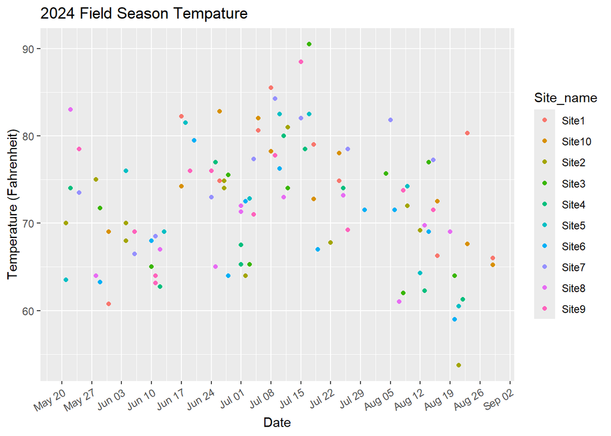

```r
DG1 <- ggplot(Daily, aes(x=Date, y=Temp_mean, color = Site_name)) +
  geom_point() +
  xlab("Date") +
  ylab("Temperature (Fahrenheit)") +
  ggtitle("2024 Field Season Tempature") +
  scale_x_date(date_labels = "%b %d", date_breaks = "1 week") +
  theme(axis.text.x = element_text(angle = 30, hjust = 1))
print(DG1)
```

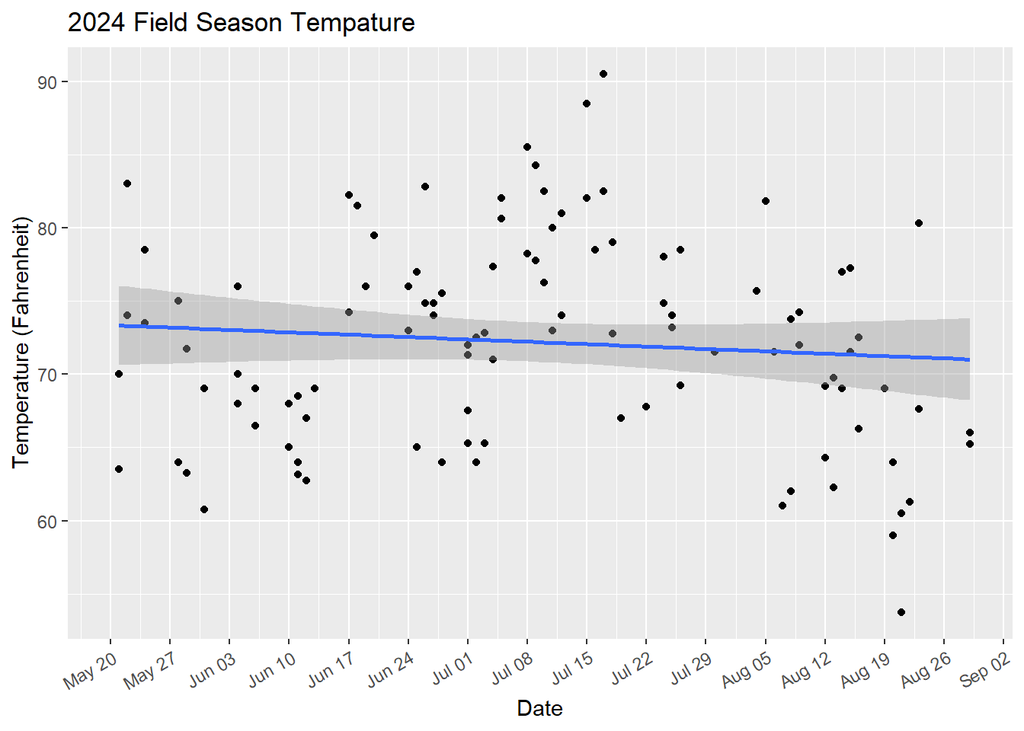

```r
DG2 <- ggplot(Daily, aes(x=Date, y=Temp_mean)) +
 # geom_line() +
  geom_point() +
 # stat_summary(aes(group = 1), fun.y = "mean", geom = "line") +
  stat_smooth(method = glm) +
  xlab("Date") +
  ylab("Temperature (Fahrenheit)") +
  ggtitle("2024 Field Season Tempature") +
  scale_x_date(date_labels = "%b %d", date_breaks = "1 week") +
  theme(axis.text.x = element_text(angle = 30, hjust = 1))
print(DG2)
```

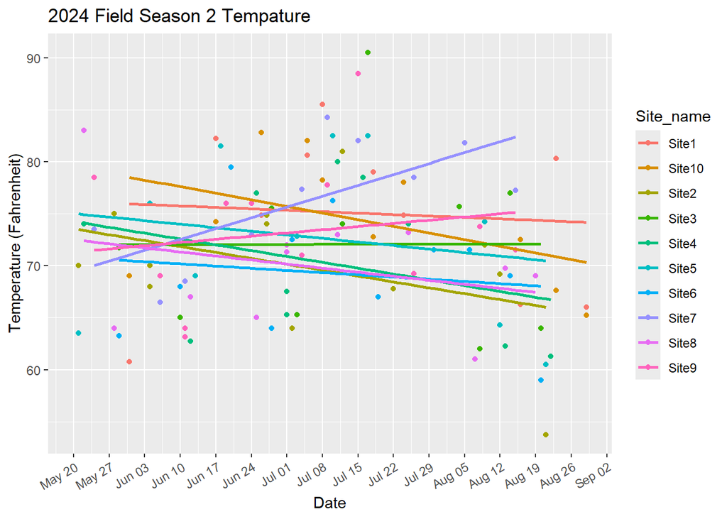

```r
DG3 <- ggplot(Daily, aes(x=Date, y=Temp_mean, color=Site_name)) +
 # geom_line() +
  geom_point() +
 # stat_summary(aes(group = 1), fun.y = "mean", geom = "line") +
  stat_smooth(method = glm, se=FALSE) +
  xlab("Date") +
  ylab("Temperature (Fahrenheit)") +
  ggtitle("2024 Field Season 2 Tempature") +
  scale_x_date(date_labels = "%b %d", date_breaks = "1 week") +
  theme(axis.text.x = element_text(angle = 30, hjust = 1))
print(DG3)
```

**1.3:** Temperature is divided by site in a grid, line of dots per recorded visit temp by date.

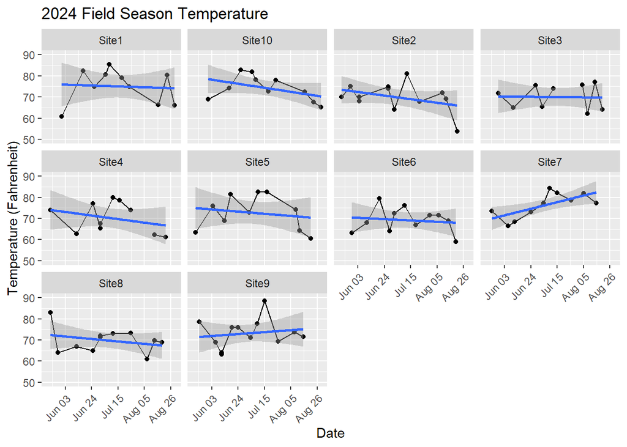

```r
DG4 <- ggplot(Daily, aes(x=Date, y=Temp_mean)) +
  geom_point() +
  geom_line() +
  geom_smooth(method = "glm") +
    #method = "loess") +
  scale_y_continuous(limits = c(50, 90)) +
  theme(axis.text.x = element_text(angle = 45, hjust = 1)) +
  #stat_summary(aes(group = 1), fun.y = "mean", geom = "line") +
  xlab("Date") +
  ylab("Temperature (Fahrenheit)") +
  ggtitle("2024 Field Season Temperature") +
  scale_x_date(date_labels = "%b %d", date_breaks = "3 week") +
  facet_wrap(vars(Site_name))
print(DG4)
```

Average documented tempature across all sites

```r
Avg_Temp <- Daily %>%
  group_by(Date, Month) %>%
  summarise(Avgtemp = mean(Temp_mean, na.rm = TRUE))
```

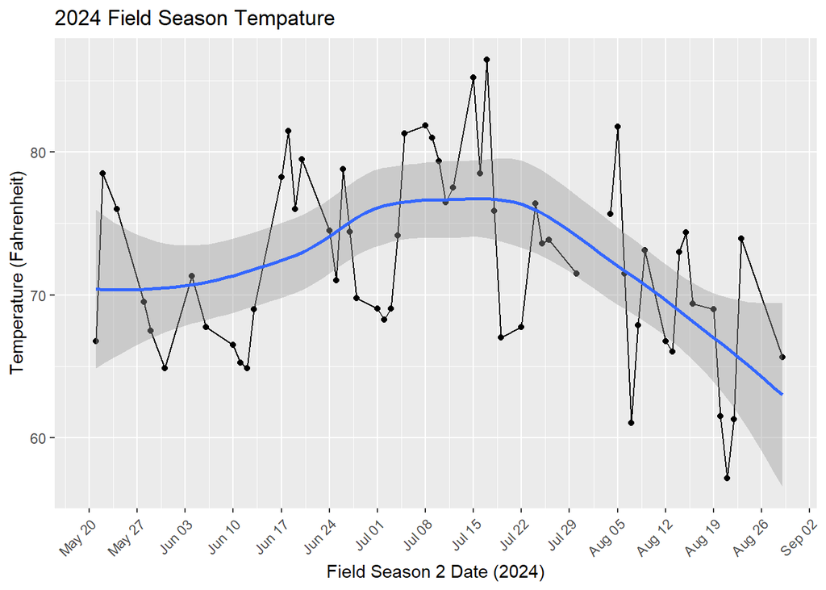

```r
DG5 <- ggplot(Avg_Temp, aes(x=Date, y=Avgtemp)) +
  geom_point() +
  geom_line() +
  geom_smooth(method = "loess") + #makes a more fitted curvey line
  #stat_summary(aes(group = 1), fun.y = "mean", geom = "line") +
  #stat_smooth(method = lm) +
  theme(axis.text.x = element_text(angle = 45, hjust = 1)) +
  xlab("Field Season 2 Date (2024)") +
  ylab("Temperature (Fahrenheit)") +
  ggtitle("2024 Field Season Tempature") +
  scale_x_date(date_labels = "%b %d", date_breaks = "1 week")
print(DG5)
```

# Box plots

**1.4:** Temperature is divided by all the months where all the sites are together. I think this is the **best** one.

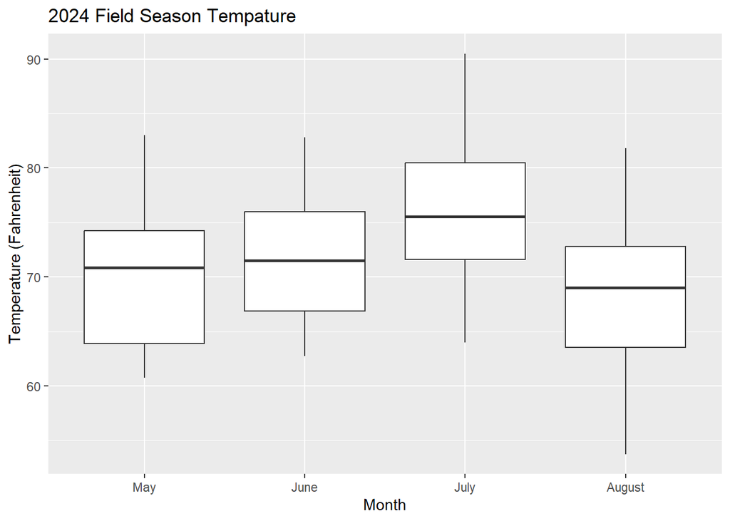

```r
BP1 <- ggplot(Daily, aes(x=Month, y=Temp_mean)) +
  geom_boxplot() +
  xlab("Month") +
  ylab("Temperature (Fahrenheit)") +
  ggtitle("2024 Field Season Tempature")
print(BP1)
```

**1.5:** Temperature is divided by month in each box plot and each site is seperate in the grid.

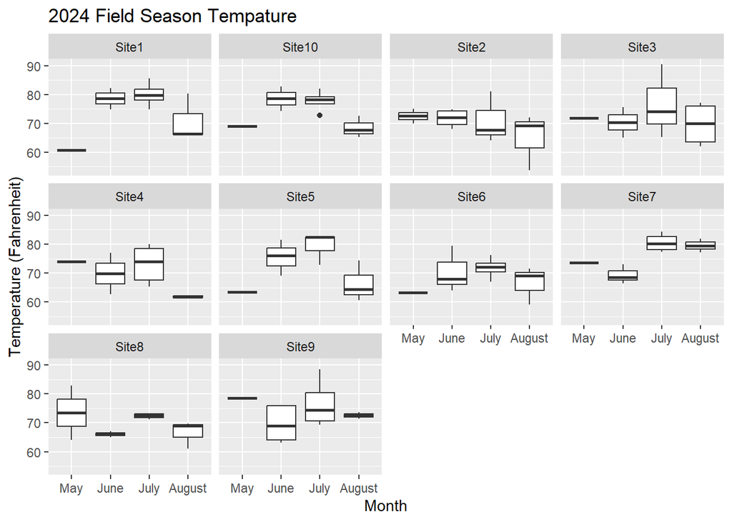

```r
BP2 <- ggplot(Daily, aes(x=Month, y=Temp_mean)) +
  geom_boxplot() +
  xlab("Month") +
  ylab("Temperature (Fahrenheit)") +
  ggtitle("2024 Field Season Tempature") +
  facet_wrap(vars(Site_name))
print(BP2)
```